# Introduction à GeoPandas

Ce didacticiel rapide présente les concepts clés et les fonctionnalités de base de GeoPandas pour vous aider à démarrer vos projets.

## Concepts

GeoPandas, comme son nom l'indique, étend la populaire bibliothèque de science des données [pandas](https://pandas.pydata.org) en ajoutant la prise en charge des données géospatiales. Si vous n'êtes pas familier avec « pandas », nous vous recommandons de jeter un coup d'œil rapide à sa [documentation de démarrage](https://pandas.pydata.org/docs/getting_started/index.html#getting-started) avant de continuer.

La structure de données de base de GeoPandas est « geopandas.GeoDataFrame », une sous-classe de « pandas.DataFrame », qui peut stocker des colonnes géométriques et effectuer des opérations spatiales. Le `geopandas.GeoSeries`, une sous-classe de `pandas.Series`, gère les géométries. Par conséquent, votre `GeoDataFrame` est une combinaison de `pandas.Series`, avec des données traditionnelles (numériques, booléennes, texte, etc.), et de `geopandas.GeoSeries`, avec des géométries (points, polygones, etc.). Vous pouvez avoir autant de colonnes avec des géométries que vous le souhaitez ; il n'y a pas de limite typique pour les logiciels SIG de bureau.

[figure not shown]

Chaque « GeoSeries » peut contenir n'importe quel type de géométrie (vous pouvez même les mélanger dans un seul tableau) et possède un attribut « GeoSeries.crs », qui stocke des informations sur la projection (CRS signifie Coordonnées Reference System). Par conséquent, chaque `GeoSeries` dans un `GeoDataFrame` peut se trouver dans une projection différente, vous permettant par exemple d'avoir plusieurs versions (projections différentes) de la même géométrie.

Une seule `GeoSeries` dans un `GeoDataFrame` est considérée comme la géométrie *active*, ce qui signifie que toutes les opérations géométriques appliquées à un `GeoDataFrame` opèrent sur cette colonne *active*.

Mode d'emploi

En savoir plus sur les [structures de données](https://geopandas.org/docs/user_guide/data_structures.rst) dans le guide de l'utilisateur.

Voyons comment certains de ces concepts fonctionnent dans la pratique.

## Lecture et écriture de fichiers

Tout d’abord, nous devons lire certaines données.

### Lecture de fichiers

```python
import geopandas
import fiona
gpkg = "./data/bouira_com.gpkg"
layers = fiona.listlayers(gpkg)
layers
```

```
['landuse',
 'Autoroute',
 'place',
 'output',
 'waterway',
 'lac',
 'batiments',
 'Autoroutes',
 'places',
 'cbouira']
```

```python
path_to_data ="./data/wbouira.shp"
gdf = geopandas.read_file(path_to_data)

gdf
```

|  | ID_0 | ISO | NAME_0 | ID_1 | NAME_1 | ID_2 | NAME_2 | TYPE_2 | ENGTYPE_2 | X | Y | Population | superficie | geometry |
| --- | --- | --- | --- | --- | --- | --- | --- | --- | --- | --- | --- | --- | --- | --- |
| 0 | 5 | DZA | Algeria | 12 | Bouira | 353 | AGHBALOU | Commune | Commune | None | None | None | None | POLYGON ((478679.140 4354598.121, 478546.437 4... |
| 1 | 5 | DZA | Algeria | 12 | Bouira | 354 | AHL-EL-KSAR | Commune | Commune | None | None | None | None | POLYGON ((458096.559 4339404.491, 458085.518 4... |
| 2 | 5 | DZA | Algeria | 12 | Bouira | 355 | AHNIF | Commune | Commune | None | None | None | None | POLYGON ((473835.421 4332764.866, 473715.086 4... |
| 3 | 5 | DZA | Algeria | 12 | Bouira | 356 | AIN-BESSEM | Commune | Commune | None | None | None | None | POLYGON ((410218.793 4335155.776, 410175.479 4... |
| 4 | 5 | DZA | Algeria | 12 | Bouira | 357 | AIN-EL-HADJAR | Commune | Commune | None | None | None | None | POLYGON ((426730.571 4349243.480, 426751.618 4... |
| 5 | 5 | DZA | Algeria | 12 | Bouira | 358 | AIN-LALOUI | Commune | Commune | None | None | None | None | POLYGON ((414504.920 4348625.545, 414544.439 4... |
| 6 | 5 | DZA | Algeria | 12 | Bouira | 359 | AIN-TURK | Commune | Commune | None | None | None | None | POLYGON ((428803.448 4359789.178, 428789.328 4... |
| 7 | 5 | DZA | Algeria | 12 | Bouira | 360 | AIT-LAAZIZ | Commune | Commune | None | None | None | None | POLYGON ((438557.715 4363083.038, 438550.470 4... |
| 8 | 5 | DZA | Algeria | 12 | Bouira | 361 | AOMAR | Commune | Commune | None | None | None | None | POLYGON ((427249.759 4363316.919, 427215.814 4... |
| 9 | 5 | DZA | Algeria | 12 | Bouira | 362 | ATH-MANSOUR | Commune | Commune | None | None | None | None | POLYGON ((476926.874 4347296.472, 476937.331 4... |
| 10 | 5 | DZA | Algeria | 12 | Bouira | 363 | BECHLOUL | Commune | Commune | None | None | None | None | POLYGON ((448654.516 4340431.766, 448587.580 4... |
| 11 | 5 | DZA | Algeria | 12 | Bouira | 364 | BIR-GHBALOU | Commune | Commune | None | None | None | None | POLYGON ((405529.010 4338312.000, 405500.293 4... |
| 12 | 5 | DZA | Algeria | 12 | Bouira | 365 | BORDJ-OKHRISS | Commune | Commune | None | None | None | None | POLYGON ((426167.406 4307012.819, 426155.834 4... |
| 13 | 5 | DZA | Algeria | 12 | Bouira | 366 | BOUDERBALA | Commune | Commune | None | None | None | None | POLYGON ((392844.922 4384172.391, 393300.784 4... |
| 14 | 5 | DZA | Algeria | 12 | Bouira | 367 | BOUIRA | Chef-Lieu-Wilaya | Chef-Lieu-Wilaya | None | None | None | None | POLYGON ((426730.571 4349243.480, 426779.672 4... |
| 15 | 5 | DZA | Algeria | 12 | Bouira | 368 | BOUKRAM | Commune | Commune | None | None | None | None | POLYGON ((367367.903 4376059.806, 367446.384 4... |
| 16 | 5 | DZA | Algeria | 12 | Bouira | 369 | CHORFA | Commune | Commune | None | None | None | None | POLYGON ((482711.458 4348736.265, 482508.635 4... |
| 17 | 5 | DZA | Algeria | 12 | Bouira | 370 | DECHMIA | Commune | Commune | None | None | None | None | POLYGON ((408931.705 4328727.688, 408930.484 4... |
| 18 | 5 | DZA | Algeria | 12 | Bouira | 371 | DIRRAH | Commune | Commune | None | None | None | None | POLYGON ((425063.899 4306334.275, 424907.601 4... |
| 19 | 5 | DZA | Algeria | 12 | Bouira | 372 | DJEBAHIA | Commune | Commune | None | None | None | None | POLYGON ((420478.102 4359749.067, 420458.276 4... |
| 20 | 5 | DZA | Algeria | 12 | Bouira | 373 | EL-ADJIBA | Commune | Commune | None | None | None | None | POLYGON ((460499.867 4340479.707, 460328.679 4... |
| 21 | 5 | DZA | Algeria | 12 | Bouira | 374 | EL-ASNAM | Commune | Commune | None | None | None | None | POLYGON ((448654.516 4340431.766, 448578.928 4... |
| 22 | 5 | DZA | Algeria | 12 | Bouira | 375 | EL-HACHIMIA | Commune | Commune | None | None | None | None | POLYGON ((422183.497 4320581.606, 422180.949 4... |
| 23 | 5 | DZA | Algeria | 12 | Bouira | 376 | EL-HAKIMIA | Commune | Commune | None | None | None | None | POLYGON ((426167.406 4307012.819, 426180.092 4... |
| 24 | 5 | DZA | Algeria | 12 | Bouira | 377 | EL-KHABOUZIA | Commune | Commune | None | None | None | None | POLYGON ((406837.782 4338739.186, 406761.875 4... |
| 25 | 5 | DZA | Algeria | 12 | Bouira | 378 | EL-MOKRANI | Commune | Commune | None | None | None | None | POLYGON ((396860.440 4360082.101, 396878.913 4... |
| 26 | 5 | DZA | Algeria | 12 | Bouira | 379 | GUERROUMA | Commune | Commune | None | None | None | None | POLYGON ((389988.008 4371789.183, 389836.169 4... |
| 27 | 5 | DZA | Algeria | 12 | Bouira | 380 | HADJERA-ZERGA | Commune | Commune | None | None | None | None | POLYGON ((426299.313 4306507.583, 426368.239 4... |
| 28 | 5 | DZA | Algeria | 12 | Bouira | 381 | HAIZER | Commune | Commune | None | None | None | None | POLYGON ((438349.557 4351516.227, 438372.700 4... |
| 29 | 5 | DZA | Algeria | 12 | Bouira | 382 | KADIRIA | Commune | Commune | None | None | None | None | POLYGON ((405093.292 4365529.805, 405058.232 4... |
| 30 | 5 | DZA | Algeria | 12 | Bouira | 383 | LAKHDARIA | Commune | Commune | None | None | None | None | POLYGON ((400237.763 4373757.549, 400226.191 4... |
| 31 | 5 | DZA | Algeria | 12 | Bouira | 384 | M'CHEDALLAH | Commune | Commune | None | None | None | None | POLYGON ((464933.002 4354447.250, 465100.739 4... |
| 32 | 5 | DZA | Algeria | 12 | Bouira | 385 | MAALA | Commune | Commune | None | None | None | None | POLYGON ((397325.432 4361620.207, 397313.277 4... |
| 33 | 5 | DZA | Algeria | 12 | Bouira | 386 | MAAMOURA | Commune | Commune | None | None | None | None | POLYGON ((407438.423 4292686.264, 407420.773 4... |
| 34 | 5 | DZA | Algeria | 12 | Bouira | 387 | MEZDOUR | Commune | Commune | None | None | None | None | POLYGON ((452784.132 4306053.836, 452773.782 4... |
| 35 | 5 | DZA | Algeria | 12 | Bouira | 388 | OUED-EL-BERDI | Commune | Commune | None | None | None | None | POLYGON ((444351.456 4326332.939, 444341.318 4... |
| 36 | 5 | DZA | Algeria | 12 | Bouira | 389 | OULED-RACHED | Commune | Commune | None | None | None | None | POLYGON ((444341.318 4326327.678, 444351.456 4... |
| 37 | 5 | DZA | Algeria | 12 | Bouira | 390 | RAOURAOUA | Commune | Commune | None | None | None | None | POLYGON ((396032.001 4329097.130, 396155.680 4... |
| 38 | 5 | DZA | Algeria | 12 | Bouira | 391 | RIDANE | Commune | Commune | None | None | None | None | POLYGON ((385453.090 4305955.631, 385272.083 4... |
| 39 | 5 | DZA | Algeria | 12 | Bouira | 392 | SAHARIDJ | Commune | Commune | None | None | None | None | POLYGON ((476714.708 4354724.728, 476383.056 4... |
| 40 | 5 | DZA | Algeria | 12 | Bouira | 393 | SOUK-EL-KHEMIS | Commune | Commune | None | None | None | None | POLYGON ((404434.394 4347814.163, 404346.465 4... |
| 41 | 5 | DZA | Algeria | 12 | Bouira | 394 | SOUR-EL-GHOZLANE | Commune | Commune | None | None | None | None | POLYGON ((408931.705 4328727.688, 408964.217 4... |
| 42 | 5 | DZA | Algeria | 12 | Bouira | 395 | TAGHZOUT | Commune | Commune | None | None | None | None | POLYGON ((438557.715 4363083.038, 438838.144 4... |
| 43 | 5 | DZA | Algeria | 12 | Bouira | 396 | TAGUEDITE | Commune | Commune | None | None | None | None | POLYGON ((448194.885 4281452.803, 448058.944 4... |
| 44 | 5 | DZA | Algeria | 12 | Bouira | 397 | Z'BARBAR | Commune | Commune | None | None | None | None | POLYGON ((396860.440 4360082.101, 396647.372 4... |

### Écriture de fichiers

Pour réécrire un `GeoDataFrame` dans un fichier, utilisez `GeoDataFrame.to_file()`. Le format de fichier par défaut est Shapefile, mais vous pouvez spécifier le vôtre avec le mot-clé « driver ».

```python
gdf.to_file("./data/w10.geojson", driver="GeoJSON")
```

Mode d'emploi

En savoir plus sur [lecture et écriture de fichiers](https://geopandas.org/docs/user_guide/io.rst) dans le guide de l'utilisateur.

## Accesseurs et méthodes simples

Nous avons maintenant notre `GeoDataFrame` et pouvons commencer à travailler avec sa géométrie.

Puisqu'il n'y avait qu'une seule colonne de géométrie dans l'ensemble de données `wbouira`, cette colonne devient automatiquement la géométrie *active* et les méthodes spatiales utilisées sur `GeoDataFrame` seront appliquées à la colonne `"géométrie"`.

### Zone de mesure

Mais d’abord, pour faciliter la lecture des résultats, fixez les noms des communes comme index :

```python
gdf = gdf.set_index("NAME_2")
```

```python
gdf["area"] = gdf.area
gdf["area"]
```

```
NAME_2
AGHBALOU            9.445325e+07
AHL-EL-KSAR         1.608416e+08
AHNIF               2.457391e+08
AIN-BESSEM          1.966776e+08
AIN-EL-HADJAR       1.137805e+08
AIN-LALOUI          9.002173e+07
AIN-TURK            6.420755e+07
AIT-LAAZIZ          5.733735e+07
AOMAR               1.098754e+08
ATH-MANSOUR         1.381353e+08
BECHLOUL            1.372009e+08
BIR-GHBALOU         7.717678e+07
BORDJ-OKHRISS       2.381300e+08
BOUDERBALA          7.239335e+07
BOUIRA              1.491963e+08
BOUKRAM             1.457795e+08
CHORFA              4.744457e+07
DECHMIA             2.311780e+08
DIRRAH              3.605754e+08
DJEBAHIA            1.113512e+08
EL-ADJIBA           1.270682e+08
EL-ASNAM            1.778374e+08
EL-HACHIMIA         3.824290e+08
EL-HAKIMIA          1.052783e+08
EL-KHABOUZIA        7.787931e+07
EL-MOKRANI          8.618230e+07
GUERROUMA           1.489675e+08
HADJERA-ZERGA       2.265320e+08
HAIZER              1.373237e+08
KADIRIA             1.450057e+08
LAKHDARIA           1.436148e+08
M'CHEDALLAH         8.754127e+07
MAALA               8.558745e+07
MAAMOURA            1.792517e+08
MEZDOUR             2.246167e+08
OUED-EL-BERDI       1.737984e+08
OULED-RACHED        2.269781e+08
RAOURAOUA           1.080184e+08
RIDANE              1.190223e+08
SAHARIDJ            1.452801e+08
SOUK-EL-KHEMIS      1.007627e+08
SOUR-EL-GHOZLANE    2.714667e+08
TAGHZOUT            7.125974e+07
TAGUEDITE           4.012711e+08
Z'BARBAR            9.071718e+07
Name: area, dtype: float64
```

### Obtenir la limite du polygone et le centre de gravité

Pour obtenir la limite de chaque polygone (LineString), accédez au `GeoDataFrame.boundary` :

```python
gdf["boundary"] = gdf.boundary
gdf["boundary"]
```

```
NAME_2
AGHBALOU            LINESTRING (478679.140 4354598.121, 478546.437...
AHL-EL-KSAR         LINESTRING (458096.559 4339404.491, 458085.518...
AHNIF               LINESTRING (473835.421 4332764.866, 473715.086...
AIN-BESSEM          LINESTRING (410218.793 4335155.776, 410175.479...
AIN-EL-HADJAR       LINESTRING (426730.571 4349243.480, 426751.618...
AIN-LALOUI          LINESTRING (414504.920 4348625.545, 414544.439...
AIN-TURK            LINESTRING (428803.448 4359789.178, 428789.328...
AIT-LAAZIZ          LINESTRING (438557.715 4363083.038, 438550.470...
AOMAR               LINESTRING (427249.759 4363316.919, 427215.814...
ATH-MANSOUR         LINESTRING (476926.874 4347296.472, 476937.331...
BECHLOUL            LINESTRING (448654.516 4340431.766, 448587.580...
BIR-GHBALOU         LINESTRING (405529.010 4338312.000, 405500.293...
BORDJ-OKHRISS       LINESTRING (426167.406 4307012.819, 426155.834...
BOUDERBALA          LINESTRING (392844.922 4384172.391, 393300.784...
BOUIRA              LINESTRING (426730.571 4349243.480, 426779.672...
BOUKRAM             LINESTRING (367367.903 4376059.806, 367446.384...
CHORFA              LINESTRING (482711.458 4348736.265, 482508.635...
DECHMIA             LINESTRING (408931.705 4328727.688, 408930.484...
DIRRAH              LINESTRING (425063.899 4306334.275, 424907.601...
DJEBAHIA            LINESTRING (420478.102 4359749.067, 420458.276...
EL-ADJIBA           LINESTRING (460499.867 4340479.707, 460328.679...
EL-ASNAM            LINESTRING (448654.516 4340431.766, 448578.928...
EL-HACHIMIA         LINESTRING (422183.497 4320581.606, 422180.949...
EL-HAKIMIA          LINESTRING (426167.406 4307012.819, 426180.092...
EL-KHABOUZIA        LINESTRING (406837.782 4338739.186, 406761.875...
EL-MOKRANI          LINESTRING (396860.440 4360082.101, 396878.913...
GUERROUMA           LINESTRING (389988.008 4371789.183, 389836.169...
HADJERA-ZERGA       LINESTRING (426299.313 4306507.583, 426368.239...
HAIZER              LINESTRING (438349.557 4351516.227, 438372.700...
KADIRIA             LINESTRING (405093.292 4365529.805, 405058.232...
LAKHDARIA           LINESTRING (400237.763 4373757.549, 400226.191...
M'CHEDALLAH         LINESTRING (464933.002 4354447.250, 465100.739...
MAALA               LINESTRING (397325.432 4361620.207, 397313.277...
MAAMOURA            LINESTRING (407438.423 4292686.264, 407420.773...
MEZDOUR             LINESTRING (452784.132 4306053.836, 452773.782...
OUED-EL-BERDI       LINESTRING (444351.456 4326332.939, 444341.318...
OULED-RACHED        LINESTRING (444341.318 4326327.678, 444351.456...
RAOURAOUA           LINESTRING (396032.001 4329097.130, 396155.680...
RIDANE              LINESTRING (385453.090 4305955.631, 385272.083...
SAHARIDJ            LINESTRING (476714.708 4354724.728, 476383.056...
SOUK-EL-KHEMIS      LINESTRING (404434.394 4347814.163, 404346.465...
SOUR-EL-GHOZLANE    LINESTRING (408931.705 4328727.688, 408964.217...
TAGHZOUT            LINESTRING (438557.715 4363083.038, 438838.144...
TAGUEDITE           LINESTRING (448194.885 4281452.803, 448058.944...
Z'BARBAR            LINESTRING (396860.440 4360082.101, 396647.372...
Name: boundary, dtype: geometry
```

Puisque nous avons enregistré la limite en tant que nouvelle colonne, nous avons maintenant deux colonnes géométriques dans le même « GeoDataFrame ».

Nous pouvons également créer de nouvelles géométries, qui pourraient être, par exemple, une version tamponnée de la géométrie originale (c'est-à-dire `GeoDataFrame.buffer(10)`) ou son centroïde :

```python
gdf["centroid"] = gdf.centroid
gdf["centroid"]
```

```
NAME_2
AGHBALOU            POINT (483967.891 4358917.054)
AHL-EL-KSAR         POINT (449396.911 4334527.841)
AHNIF               POINT (467922.818 4337453.152)
AIN-BESSEM          POINT (411607.563 4347934.347)
AIN-EL-HADJAR       POINT (422172.786 4350164.057)
AIN-LALOUI          POINT (417404.635 4343653.537)
AIN-TURK            POINT (425703.733 4357433.714)
AIT-LAAZIZ          POINT (432299.564 4361973.096)
AOMAR               POINT (421128.866 4369453.781)
ATH-MANSOUR         POINT (480368.215 4341405.563)
BECHLOUL            POINT (456472.489 4350218.035)
BIR-GHBALOU         POINT (398739.676 4337159.479)
BORDJ-OKHRISS       POINT (436378.170 4312858.733)
BOUDERBALA          POINT (387918.116 4378658.675)
BOUIRA              POINT (433655.215 4351234.759)
BOUKRAM             POINT (374706.301 4372896.179)
CHORFA              POINT (482711.782 4351982.940)
DECHMIA             POINT (397371.690 4320100.278)
DIRRAH              POINT (414396.646 4301676.894)
DJEBAHIA            POINT (414579.760 4364019.400)
EL-ADJIBA           POINT (462437.543 4351179.516)
EL-ASNAM            POINT (448800.738 4349351.356)
EL-HACHIMIA         POINT (427643.620 4329353.763)
EL-HAKIMIA          POINT (422988.554 4314758.397)
EL-KHABOUZIA        POINT (400848.054 4343892.654)
EL-MOKRANI          POINT (401177.437 4359436.398)
GUERROUMA           POINT (381793.805 4365299.186)
HADJERA-ZERGA       POINT (426441.296 4291965.565)
HAIZER              POINT (447855.592 4357150.466)
KADIRIA             POINT (408800.408 4373056.032)
LAKHDARIA           POINT (399707.412 4378167.049)
M'CHEDALLAH         POINT (472900.706 4350741.492)
MAALA               POINT (397417.830 4369545.224)
MAAMOURA            POINT (400938.642 4301863.016)
MEZDOUR             POINT (451226.720 4312731.248)
OUED-EL-BERDI       POINT (436543.253 4336415.624)
OULED-RACHED        POINT (455079.976 4326036.159)
RAOURAOUA           POINT (403215.073 4330613.909)
RIDANE              POINT (388432.582 4309500.425)
SAHARIDJ            POINT (472671.102 4359747.341)
SOUK-EL-KHEMIS      POINT (404849.800 4353976.349)
SOUR-EL-GHOZLANE    POINT (411744.813 4322164.411)
TAGHZOUT            POINT (441711.130 4359793.974)
TAGUEDITE           POINT (439925.108 4295706.069)
Z'BARBAR            POINT (391901.705 4366136.052)
Name: centroid, dtype: geometry
```

### Mesurer la distance

Nous pouvons également mesurer la distance entre chaque centroïde et le premier emplacement du centroïde.

```python
first_point = gdf["centroid"].iloc[0]
gdf["distance"] = gdf["centroid"].distance(first_point)
gdf["distance"]
```

```
NAME_2
AGHBALOU                 0.000000
AHL-EL-KSAR          42308.230862
AHNIF                26798.198987
AIN-BESSEM           73189.049553
AIN-EL-HADJAR        62411.938072
AIN-LALOUI           68290.863916
AIN-TURK             58283.037010
AIT-LAAZIZ           51758.626213
AOMAR                63716.291233
ATH-MANSOUR          17877.638965
BECHLOUL             28838.690628
BIR-GHBALOU          87961.587212
BORDJ-OKHRISS        66228.019182
BOUDERBALA           98057.589366
BOUIRA               50895.805479
BOUKRAM             110152.217999
CHORFA                7046.967222
DECHMIA              94898.072835
DIRRAH               90092.141701
DJEBAHIA             69575.474495
EL-ADJIBA            22878.491527
EL-ASNAM             36444.906744
EL-HACHIMIA          63611.411331
EL-HAKIMIA           75289.219632
EL-KHABOUZIA         84466.797564
EL-MOKRANI           82792.083218
GUERROUMA           102373.216543
HADJERA-ZERGA        88271.235569
HAIZER               36155.483566
KADIRIA              76485.692594
LAKHDARIA            86431.421469
M'CHEDALLAH          13759.447742
MAALA                87200.177943
MAAMOURA            100742.342113
MEZDOUR              56613.717220
OUED-EL-BERDI        52492.005988
OULED-RACHED         43768.308832
RAOURAOUA            85569.186783
RIDANE              107559.279036
SAHARIDJ             11327.260326
SOUK-EL-KHEMIS       79272.207661
SOUR-EL-GHOZLANE     81036.595111
TAGHZOUT             42265.859471
TAGUEDITE            77041.516868
Z'BARBAR             92348.776383
Name: distance, dtype: float64
```

Notez que `geopandas.GeoDataFrame` est une sous-classe de `pandas.DataFrame`, nous disposons donc de toutes les fonctionnalités pandas disponibles à utiliser sur l'ensemble de données géospatiales — nous pouvons même effectuer des manipulations de données avec les attributs et les informations géométriques ensemble.

Par exemple, pour calculer la moyenne des distances mesurées ci-dessus, accédez à la colonne 'distance' et appelez la méthode mean() dessus :

```python
gdf["distance"].mean()
```

```
63435.04627040219
```

## Créer des cartes

Les GeoPandas peuvent également tracer des cartes, afin que nous puissions vérifier comment les géométries apparaissent dans l'espace. Pour tracer la géométrie active, appelez `GeoDataFrame.plot()`. Pour coder en couleur une autre colonne, transmettez cette colonne comme premier argument. Dans l'exemple ci-dessous, nous traçons la colonne de géométrie active et le code couleur par la colonne « zone ». Nous voulons également afficher une légende (`legend=True`).

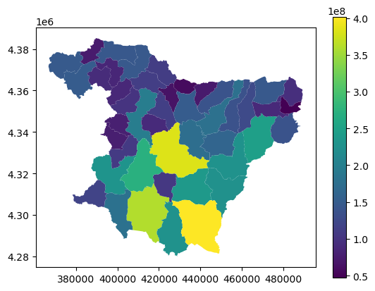

```python
gdf.plot("area", legend=True)
```

Vous pouvez également explorer vos données de manière interactive en utilisant `GeoDataFrame.explore()`, qui se comporte de la même manière que `plot()` mais renvoie une carte interactive à la place.

```python
gdf.explore("area", legend=False)
```

[interactive chart not shown]

En basculant la géométrie active (`GeoDataFrame.set_geometry`) vers les centroïdes, nous pouvons tracer les mêmes données en utilisant la géométrie des points.

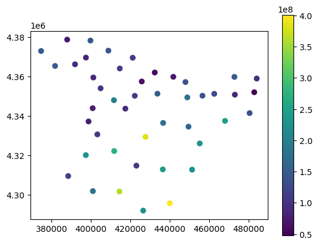

```python
gdf = gdf.set_geometry("centroid")
gdf.plot("area", legend=True)
```

Et nous pouvons également superposer les deux « GeoSeries ». Nous avons juste besoin d’utiliser une parcelle comme axe pour l’autre.

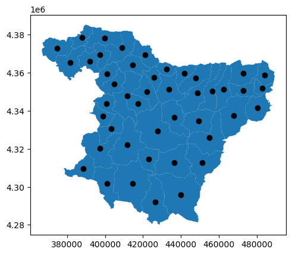

```python
ax = gdf["geometry"].plot()
gdf["centroid"].plot(ax=ax, color="black")
```

Maintenant, nous redéfinissons la géométrie active sur la « GeoSeries » d'origine.

```python
gdf = gdf.set_geometry("geometry")
```

Mode d'emploi

En savoir plus sur la [cartographie](https://geopandas.org/docs/user_guide/mapping.rst) dans le guide de l'utilisateur.